# Expected answers

2023-09-26

## Part 1: body mass and metabolic rate

```
## # A tibble: 6 × 3
##   body_mass metabolic_rate family
##       <dbl>          <dbl> <chr>
## 1     32000           50.0 Antilocapridae
## 2     37800           52.0 Antilocapridae
## 3    347000          307.  Bovidae
## 4      4200           10.1 Bovidae
## 5    196500          230.  Bovidae
## 6    100000          149.  Bovidae
```

Answer: It’s a tibble. There are three columns.

```
## [1] 25  3
```

Answer: 25 rows, 3 columns

```
## [1] TRUE
```

Answer: we had seen with `head` that this is a tibble. The `is.tibble` command confirms this by returning `TRUE`.

```
## spc_tbl_ [25 × 3] (S3: spec_tbl_df/tbl_df/tbl/data.frame)
##  $ body_mass     : num [1:25] 32000 37800 347000 4200 196500 ...
##  $ metabolic_rate: num [1:25] 50 52 306.8 10.1 230.1 ...
##  $ family        : chr [1:25] "Antilocapridae" "Antilocapridae" "Bovidae" "Bovidae" ...
##  - attr(*, "spec")=
##   .. cols(
##   ..   body_mass = col_double(),
##   ..   metabolic_rate = col_double(),
##   ..   family = col_character()
##   .. )
##  - attr(*, "problems")=<externalptr>
```

Answer:

- body_mass: numeric
- metabolic_rate: numeric
- family: character

```
## [1] "Antilocapridae" "Bovidae"        "Camelidae"      "Canidae"
## [5] "Cervidae"       "Suidae"         "Tayassuidae"    "Tragulidae"
```

Answer: The levels for `mass_metabolism2$family` are:

“Antilocapridae” “Bovidae” “Camelidae” “Canidae”  
“Cervidae” “Suidae” “Tayassuidae” “Tragulidae”

```
##    body_mass      metabolic_rate       family
##  Min.   :  1613   Min.   :  4.865   Length:25
##  1st Qu.: 21500   1st Qu.: 46.347   Class :character
##  Median : 65320   Median :106.670   Mode  :character
##  Mean   : 99358   Mean   :112.935
##  3rd Qu.:133300   3rd Qu.:148.949
##  Max.   :407000   Max.   :306.770
```

```
##    body_mass      metabolic_rate               family
##  Min.   :  1613   Min.   :  4.865   Bovidae       :11
##  1st Qu.: 21500   1st Qu.: 46.347   Cervidae      : 5
##  Median : 65320   Median :106.670   Antilocapridae: 2
##  Mean   : 99358   Mean   :112.935   Camelidae     : 2
##  3rd Qu.:133300   3rd Qu.:148.949   Tragulidae    : 2
##  Max.   :407000   Max.   :306.770   Canidae       : 1
##                                     (Other)       : 2
```

Answer: `summary` is meaningless for a character column. Once we converted into factor, `summary` gives us counts within each category. For example, there are 11 rows where `family=='Bovidae'`.

```
##
## FALSE
##    75
```

Answer: there are no NAs.

Answer: the range in mass overall is pretty huge (405387 kg!). But the range within Bovidae alone is also very impressive: 342800, so yes, I would say yes.

Expected output:

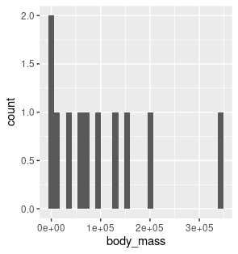

Answer: skewed right. 11.

Answer: Yes, the range in Bovidae alone (297) is almost as high as the overall range (302).

Expected output:

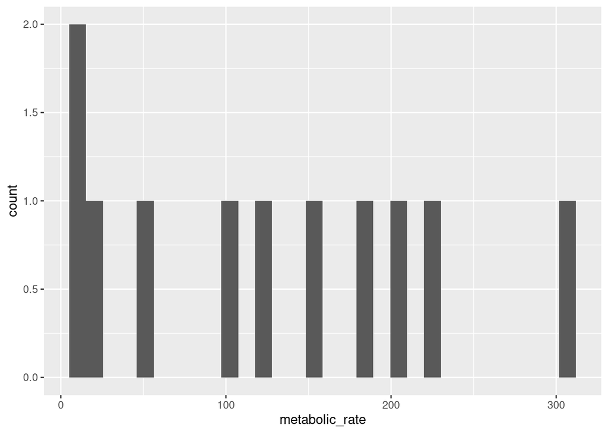

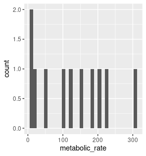

Answer: skewed right

Expected output:

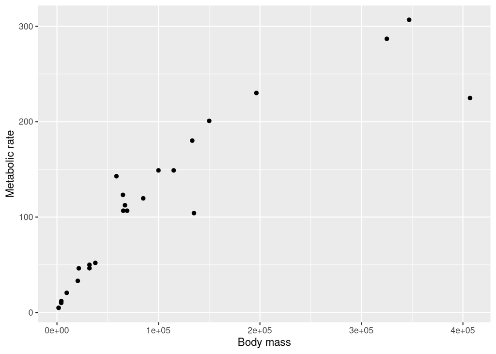

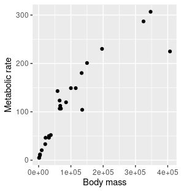

Answer: body mass (explanatory), metabolic rate (response).

Expected output:

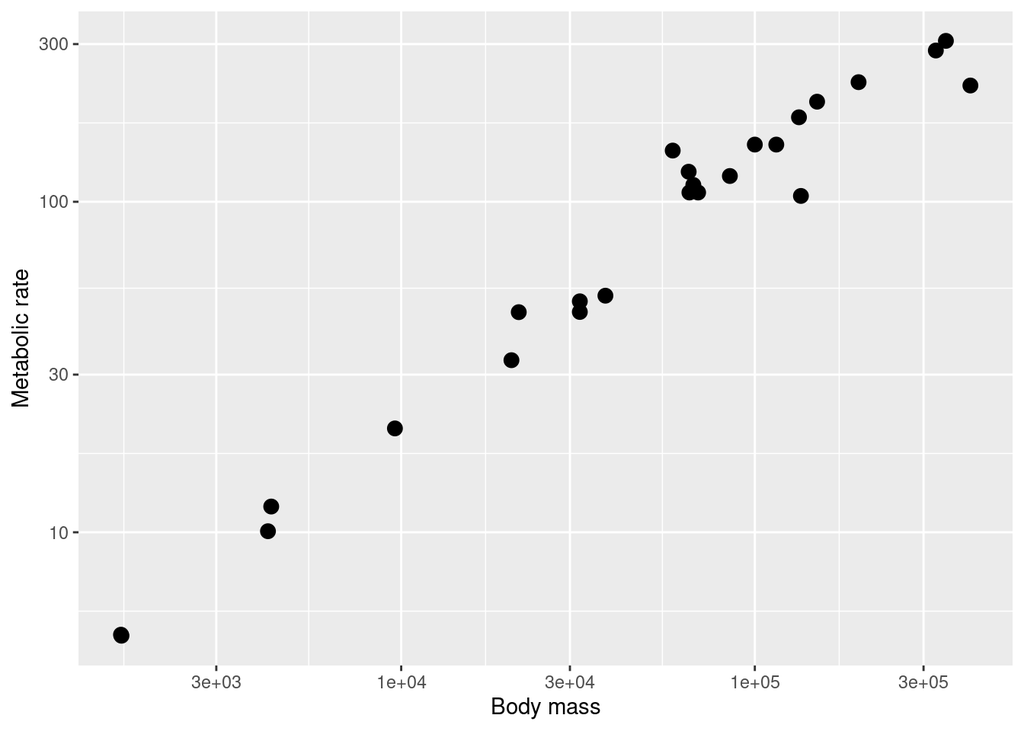

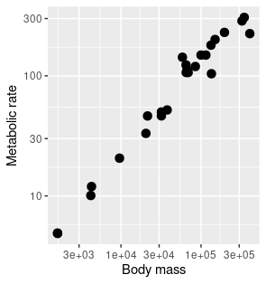

Expected output

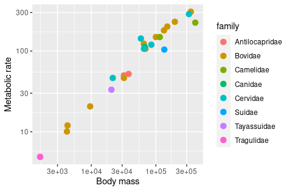

Expected output:

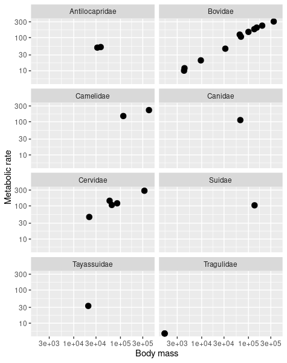

17. Expected output:

```
## # A tibble: 8 × 3
##   family             N Range_body_mass
##   <fct>          <int>           <dbl>
## 1 Antilocapridae     2            5800
## 2 Bovidae           11          342800
## 3 Camelidae          2          292000
## 4 Canidae            1               0
## 5 Cervidae           5          303500
## 6 Suidae             1               0
## 7 Tayassuidae        1               0
## 8 Tragulidae         2               5
```

Answer: because there is only one value so range cannot really be calculated.

Ex. 18

Expected output:

```
## # A tibble: 6 × 5
##    site experiment length width height
##   <dbl>      <dbl>  <dbl> <dbl>  <dbl>
## 1     1          1    2.2   1.3    9.6
## 2     1          2    2.1   2.2    7.6
## 3     1          3    2.7   1.5    2.2
## 4     2          1    3     4.5    1.5
## 5     2          2    3.1   3.1    4
## 6     2          3    2.5   2.8    3
```

```
## [1] 15  5
```

```
## spc_tbl_ [15 × 5] (S3: spec_tbl_df/tbl_df/tbl/data.frame)
##  $ site      : num [1:15] 1 1 1 2 2 2 3 3 3 4 ...
##  $ experiment: num [1:15] 1 2 3 1 2 3 1 2 3 1 ...
##  $ length    : num [1:15] 2.2 2.1 2.7 3 3.1 2.5 1.9 1.1 3.5 2.9 ...
##  $ width     : num [1:15] 1.3 2.2 1.5 4.5 3.1 2.8 1.8 0.5 2 2.7 ...
##  $ height    : num [1:15] 9.6 7.6 2.2 1.5 4 3 4.5 2.3 7.5 3.2 ...
##  - attr(*, "spec")=
##   .. cols(
##   ..   site = col_double(),
##   ..   experiment = col_double(),
##   ..   length = col_double(),
##   ..   width = col_double(),
##   ..   height = col_double()
##   .. )
##  - attr(*, "problems")=<externalptr>
```

```
##       site     experiment     length          width           height
##  Min.   :1   Min.   :1    Min.   :1.100   Min.   :0.500   Min.   :1.5
##  1st Qu.:2   1st Qu.:1    1st Qu.:2.000   1st Qu.:1.575   1st Qu.:2.7
##  Median :3   Median :2    Median :2.600   Median :2.100   Median :4.0
##  Mean   :3   Mean   :2    Mean   :2.547   Mean   :2.286   Mean   :4.6
##  3rd Qu.:4   3rd Qu.:3    3rd Qu.:3.050   3rd Qu.:2.775   3rd Qu.:6.5
##  Max.   :5   Max.   :3    Max.   :4.500   Max.   :4.800   Max.   :9.6
##                                           NA's   :1       NA's   :2
```

```
##  site  experiment     length          width           height
##  1:3   1:5        Min.   :1.100   Min.   :0.500   Min.   :1.5
##  2:3   2:5        1st Qu.:2.000   1st Qu.:1.575   1st Qu.:2.7
##  3:3   3:5        Median :2.600   Median :2.100   Median :4.0
##  4:3              Mean   :2.547   Mean   :2.286   Mean   :4.6
##  5:3              3rd Qu.:3.050   3rd Qu.:2.775   3rd Qu.:6.5
##                   Max.   :4.500   Max.   :4.800   Max.   :9.6
##                                   NA's   :1       NA's   :2
```

Answer: site and experiment were coded as `numeric` which does make sense since they are categorical variables. We change them to factors instead.

Expected output:

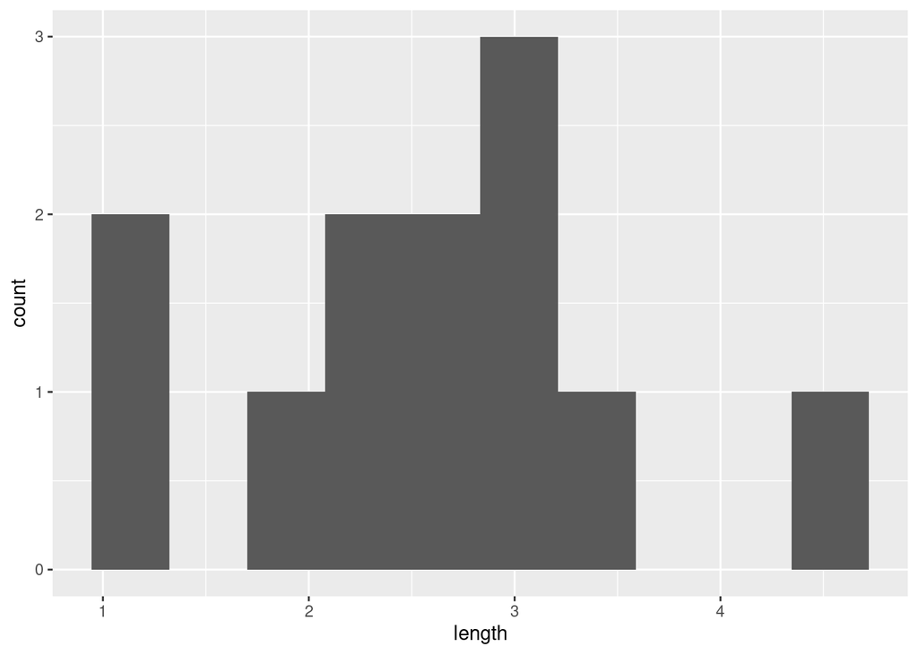

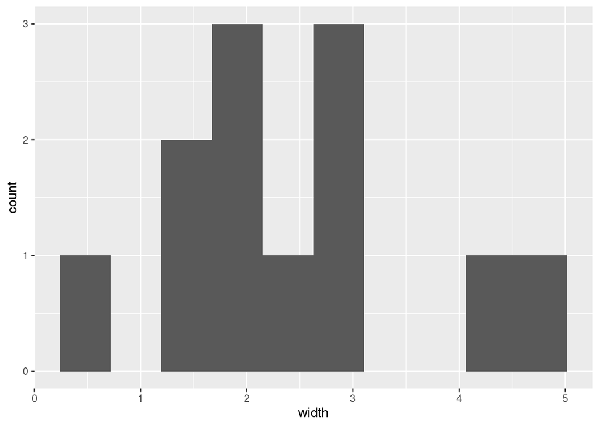

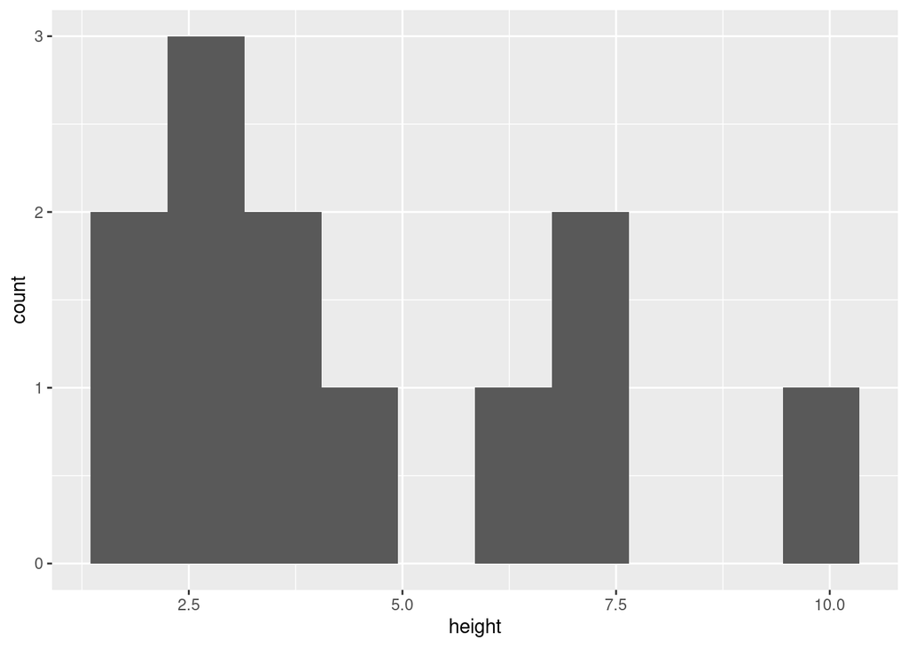

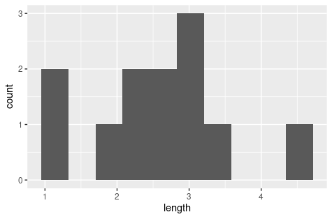

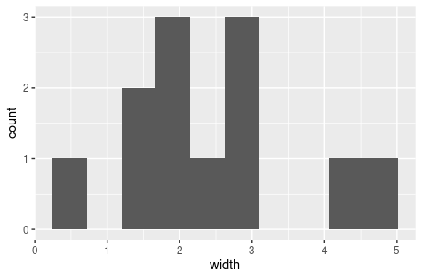

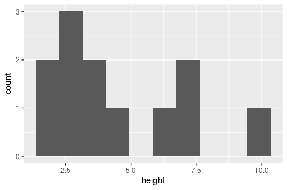

Expected output:

```
## # A tibble: 3 × 4
##   experiment     N Range_length Range_width
##   <fct>      <int>        <dbl>       <dbl>
## 1 1              4          1.1         3.2
## 2 2              4          3.4         4.3
## 3 3              4          2.3         1.3
```

21. Expected output:

```
## # A tibble: 4 × 6
##   site  experiment length width height  area
##   <fct> <fct>       <dbl> <dbl>  <dbl> <dbl>
## 1 1     2             2.1   2.2    7.6  4.62
## 2 1     1             2.2   1.3    9.6  2.86
## 3 3     3             3.5   2      7.5  7
## 4 4     2             4.5   4.8    6.5 21.6
```

Expected output:

```
## # A tibble: 2 × 5
##   site  experiment length width height
##   <fct> <fct>       <dbl> <dbl>  <dbl>
## 1 1     2             2.1   2.2    7.6
## 2 4     2             4.5   4.8    6.5
```

Expected output:

```
## # A tibble: 8 × 5
##   site  experiment length width height
##   <fct> <fct>       <dbl> <dbl>  <dbl>
## 1 1     1             2.2   1.3    9.6
## 2 1     2             2.1   2.2    7.6
## 3 2     1             3     4.5    1.5
## 4 2     2             3.1   3.1    4
## 5 3     1             1.9   1.8    4.5
## 6 3     2             1.1   0.5    2.3
## 7 4     1             2.9   2.7    3.2
## 8 4     2             4.5   4.8    6.5
```

Ex. 24

Expected output:

```
## # A tibble: 13 × 5
##     site experiment length width height
##    <dbl>      <dbl>  <dbl> <dbl>  <dbl>
##  1     1          1    2.2   1.3    9.6
##  2     1          2    2.1   2.2    7.6
##  3     1          3    2.7   1.5    2.2
##  4     2          1    3     4.5    1.5
##  5     2          2    3.1   3.1    4
##  6     2          3    2.5   2.8    3
##  7     3          1    1.9   1.8    4.5
##  8     3          2    1.1   0.5    2.3
##  9     3          3    3.5   2      7.5
## 10     4          1    2.9   2.7    3.2
## 11     4          2    4.5   4.8    6.5
## 12     4          3    1.2   1.8    2.7
## 13     5          2    1.8  NA      5.2
```

Ex. 25

Expected output: